# Assignment_MachineLearning

Eva

26 July 2014

The first step is, as always, to obtain the data and clean it up. First, the data needs to be downloaded as follows (it is already split into a training and a test set, so no need to subsequently perform a partitioning step on the datasets):

```r
fileUrl <- "https://d396qusza40orc.cloudfront.net/predmachlearn/pml-training.csv"
download.file(fileUrl, dest = "./traindata", method = "curl")

fileUrl <- "https://d396qusza40orc.cloudfront.net/predmachlearn/pml-testing.csv"
download.file(fileUrl, dest = "./testdata", method = "curl")
```

Given the inconsistent use of NA as well as empty space (i.e. no data), and the very high number of columns that almost exclusively consist of NA, this data set needs to be cleaned up considerably. The following steps read in the files, assign the NA value to both missing values as well as columns containing the value “NA”, and then remove all columns that contain NA values, as well as a few additional columns - these could be interesting for other analyses (e.g. time, subject) but all we want to look at is whether the motion data itself can predict whether this was performed correctly or if not, with which error.

```r
traindata <- read.csv("traindata", header = TRUE, sep = ",", na.strings = "")
traindata[ traindata == "NA" ] = NA
traindata <- traindata[ , ! apply( traindata , 2 , function(x) any(is.na(x)) ) ]
traindata[c(1:7)]<-list(NULL)

testdata <- read.csv("testdata", header = TRUE, sep = ",", na.strings = "")
testdata[ testdata == "NA" ] = NA
testdata <- testdata[ , ! apply( testdata , 2 , function(x) any(is.na(x)) ) ]
testdata[c(1:7)]<-list(NULL)
```

Take a first look at how messy the data is, or how clear the difference between the classes is.

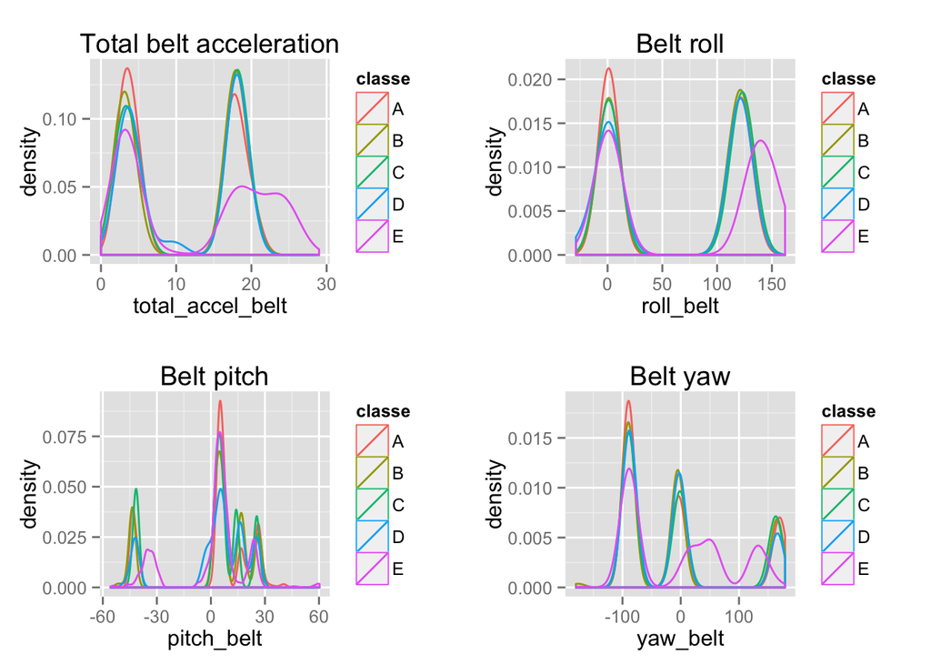

```r
library(ggplot2)
library(grid)
library(gridExtra)
p1 <- ggplot(traindata, aes(x = total_accel_belt, colour = classe)) + geom_density() + ggtitle("Total belt acceleration")
p2 <- ggplot(traindata, aes(x = roll_belt, colour = classe)) + geom_density() + ggtitle("Belt roll")
p3 <- ggplot(traindata, aes(x = pitch_belt, colour = classe)) + geom_density() + ggtitle("Belt pitch")
p4 <- ggplot(traindata, aes(x = yaw_belt, colour = classe)) + geom_density() + ggtitle("Belt yaw")
grid.arrange(p1, p2, p3, p4, ncol=2, nrow=2)
```

So far, so good - seems that there are distinct differences, and class E seems to be very different from all the others. Now just one more quick look at the summary variables for belt, arm, dumbell and forearm:

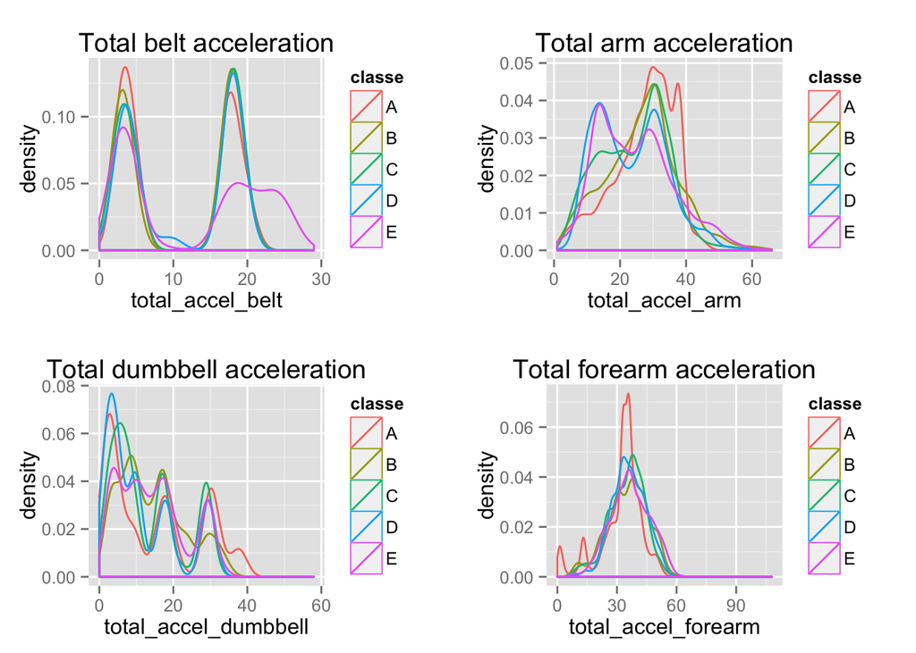

```r
p1 <- ggplot(traindata, aes(x = total_accel_belt, colour = classe)) + geom_density() + ggtitle("Total belt acceleration")
p2 <- ggplot(traindata, aes(x = total_accel_arm, colour = classe)) + geom_density() + ggtitle("Total arm acceleration")
p3 <- ggplot(traindata, aes(x = total_accel_dumbbell, colour = classe)) + geom_density() + ggtitle("Total dumbbell acceleration")
p4 <- ggplot(traindata, aes(x = total_accel_forearm, colour = classe)) + geom_density() + ggtitle("Total forearm acceleration")
grid.arrange(p1, p2, p3, p4, ncol=2, nrow=2)
```

```r
library(caret)
library(randomForest)
Modfit <- train(classe ~ ., method = "rf", data = traindata)
Modfit
```

```
## Random Forest
##
## 19622 samples
##    52 predictors
##     5 classes: 'A', 'B', 'C', 'D', 'E'
##
## No pre-processing
## Resampling: Bootstrapped (25 reps)
##
## Summary of sample sizes: 19622, 19622, 19622, 19622, 19622, 19622, ...
##
## Resampling results across tuning parameters:
##
##   mtry  Accuracy  Kappa  Accuracy SD  Kappa SD
##   2     1         1      0.001        0.002
##   30    1         1      0.001        0.001
##   50    1         1      0.004        0.005
##
## Accuracy was used to select the optimal model using  the largest value.
## The final value used for the model was mtry = 2.
```

The final Accuracy is very high; I will use this model on the test set. All predictions were correct after I submitted them, so this model seems a good approach. I have hidden the output below so it is not shown before the deadline.

```r
pred <- predict(Modfit, testdata)
pred
```

After uploading the .txt files in the automated grading section, I can see that all results are correct! So, even though it took very long for the random forest model to be generated, it seems to have been worth it. If more time were available, I would clean up the predictors more (e.g. with PCA).